# Manipulation de données avec dplyr

Mardi 25 mai 2021

## Enchaîner les commandes avec magrittr

- On utilise un opérateur

`%>%`

- Avant : `f(g(x))`
- Après : `g(x) %>% f()`

[figure not shown]

## Exemple

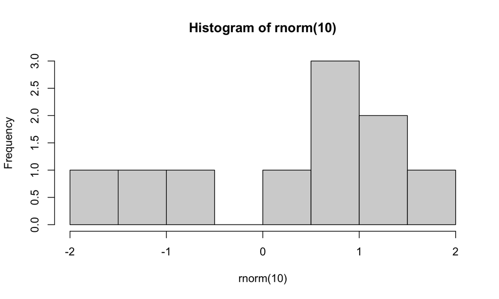

```r
set.seed(7895)

hist(rnorm(10))
```

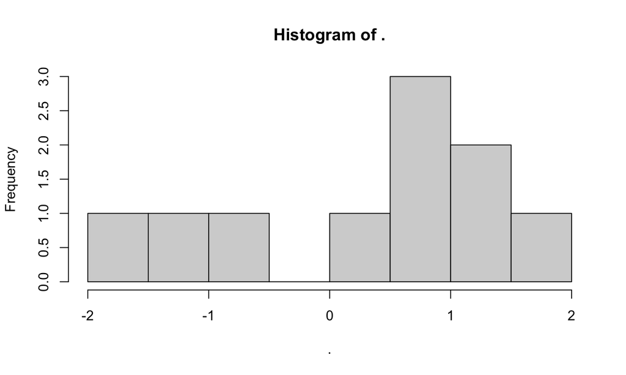

```r
library(magrittr)
set.seed(7895)
rnorm(10) %>% hist()
```

## Le tidyverse

[figure not shown]

Tidyverse: https://www.tidyverse.org/

## Avant toute chose

Charger le package `dplyr`…

```r
library(dplyr) # ou require(dplyr)
```

Ou bien charger `tidyverse`…

```r
library(tidyverse)
```

… mais cela chargera d’autres packages en plus

Et charger les données.

```r
data("fruits", package = "tidyViz")
```

## Le format “tibble”

Les données sont au format “tibble” : c’est comme des “data-frames” mais en mieux !

```r
fruits
```

```
#> # A tibble: 51 x 18
#>    nom    groupe Energie   Eau Proteines Glucides Lipides Sucres Fructose Fibres
#>    <chr>  <chr>    <dbl> <dbl>     <dbl>    <dbl>   <dbl>  <dbl>    <dbl>  <dbl>
#>  1 Abric… crus       194  87.1      0.81     9.01    0.25    6.7     1.3    1.7
#>  2 Abric… secs      1010  24.7      2.88    59.1     0.5    34.3    10.6    8.3
#>  3 Ananas exoti…     304  81.3      0.94    15.1     0.25   14.9     2.8    2.4
#>  4 Banane exoti…     383  75.8      1.06    19.7     0.25   15.6     3.8    2.7
#>  5 Canne… secs      1410  14.6      0.25    76.4     1      72.8    28.4    5.7
#>  6 Cerise crus       235  85.7      0.81    13       0.25   10       4.6    1.6
#>  7 Citron crus       118  91.3      0.25     1.56    0.25    0.8     0.4    0.25
#>  8 Cleme… crus       200  87        0.81     9.17    0.25    8.6     1.5    1.7
#>  9 Compo… compo…     279  82.9      0.25    15.3     0.08   14.6     6.92   1.6
#> 10 Compo… compo…     432  72.9      0.23    24.4     0.21   20.7     7.9    1.53
#> # … with 41 more rows, and 8 more variables: Calcium <dbl>, Magnesium <dbl>,
#> #   Phosphore <dbl>, Potassium <dbl>, Zinc <dbl>, BetaCarotene <dbl>,
#> #   VitamineE <dbl>, VitamineC <dbl>
```

## Les fonctions de dplyr

Nous allons voir ensemble quelques fonctions très pratiques de la librairie `dplyr`.

| # | Fonction (US) | Fonction (UK) | Description |
| --- | --- | --- | --- |
| 1 | `mutate` | `mutate` | Créer ou modifier des colonnes |
| 2 | `select` | `select` | Sélectionner des colonnes |
| 3 | `arrange` | `arrange` | Trier les lignes |
| 4 | `filter` | `filter` | Sélectionner des lignes |
| 5 | `group_by` | `group_by` | Grouper des lignes |
| 6 | `summarize` | `summarise` | Résumer des groupes |

## Créer ou modifier des colonnes

Avec la fonction `mutate`.

```r
fruits2 <- fruits %>%
  mutate(Sucres_ratio = Sucres / 100)

head(fruits2[, "Sucres_ratio"])
```

```
#> # A tibble: 6 x 1
#>   Sucres_ratio
#>          <dbl>
#> 1        0.067
#> 2        0.343
#> 3        0.149
#> 4        0.156
#> 5        0.728
#> 6        0.1
```

Avec les fonctions classiques.

```r
fruits2 <- fruits
fruits2$Sucres_ratio <-
  fruits2$Sucres / 100
head(fruits2[, "Sucres_ratio"])
```

```
#> # A tibble: 6 x 1
#>   Sucres_ratio
#>          <dbl>
#> 1        0.067
#> 2        0.343
#> 3        0.149
#> 4        0.156
#> 5        0.728
#> 6        0.1
```

## Sélectionner des colonnes

Avec la fonction `select`.

```r
fruits %>%
  select(
    Energie,
    Sucres,
    Lipides,
    Proteines)
```

Avec les fonctions classiques.

```r
fruits[,
  c(
    "Energie",
    "Sucres",
    "Lipides",
    "Proteines")]
```

## Trier des lignes

Avec les fonctions `arrange` et `desc`.

```r
fruits %>%
  select(Energie, Sucres, Fibres) %>%
  arrange(desc(Fibres))
```

```
#> # A tibble: 51 x 3
#>    Energie Sucres Fibres
#>      <dbl>  <dbl>  <dbl>
#>  1    1010  34.3     8.3
#>  2     425   8.5     6.8
#>  3    1410  72.8     5.7
#>  4     198   6.1     5.2
#>  5     969  38.1     5.1
#>  6     289   6.63    4.6
#>  7     206   5.4     4.3
#>  8     170   2.1     4.3
#>  9    1360  70.3     4.2
#> 10     293  12.2     4.1
#> # … with 41 more rows
```

Avec les fonctions classiques

```r
fruits[
  order(fruits$Fibres, decreasing = TRUE),
  c("Energie", "Sucres", "Fibres")]
```

```
#> # A tibble: 51 x 3
#>    Energie Sucres Fibres
#>      <dbl>  <dbl>  <dbl>
#>  1    1010  34.3     8.3
#>  2     425   8.5     6.8
#>  3    1410  72.8     5.7
#>  4     198   6.1     5.2
#>  5     969  38.1     5.1
#>  6     289   6.63    4.6
#>  7     206   5.4     4.3
#>  8     170   2.1     4.3
#>  9    1360  70.3     4.2
#> 10     293  12.2     4.1
#> # … with 41 more rows
```

## Sélectionner des lignes

Avec la fonction `filter`.

```r
fruits %>%
  filter(Sucres > 60)
```

```
#> # A tibble: 2 x 18
#>   nom     groupe Energie   Eau Proteines Glucides Lipides Sucres Fructose Fibres
#>   <chr>   <chr>    <dbl> <dbl>     <dbl>    <dbl>   <dbl>  <dbl>    <dbl>  <dbl>
#> 1 Canneb… secs      1410  14.6      0.25     76.4     1     72.8     28.4    5.7
#> 2 Raisin  secs      1360  16        3        73.2     0.9   70.3     36      4.2
#> # … with 8 more variables: Calcium <dbl>, Magnesium <dbl>, Phosphore <dbl>,
#> #   Potassium <dbl>, Zinc <dbl>, BetaCarotene <dbl>, VitamineE <dbl>,
#> #   VitamineC <dbl>
```

Avec les fonctions classiques.

```r
fruits[fruits$Sucres > 60, ]
```

```
#> # A tibble: 2 x 18
#>   nom     groupe Energie   Eau Proteines Glucides Lipides Sucres Fructose Fibres
#>   <chr>   <chr>    <dbl> <dbl>     <dbl>    <dbl>   <dbl>  <dbl>    <dbl>  <dbl>
#> 1 Canneb… secs      1410  14.6      0.25     76.4     1     72.8     28.4    5.7
#> 2 Raisin  secs      1360  16        3        73.2     0.9   70.3     36      4.2
#> # … with 8 more variables: Calcium <dbl>, Magnesium <dbl>, Phosphore <dbl>,
#> #   Potassium <dbl>, Zinc <dbl>, BetaCarotene <dbl>, VitamineE <dbl>,
#> #   VitamineC <dbl>
```

## Agréger des colonnes

Avec la fonction `group_by` :

```r
fruits %>% group_by(groupe)
```

```
#> # A tibble: 51 x 18
#> # Groups:   groupe [4]
#>    nom    groupe Energie   Eau Proteines Glucides Lipides Sucres Fructose Fibres
#>    <chr>  <chr>    <dbl> <dbl>     <dbl>    <dbl>   <dbl>  <dbl>    <dbl>  <dbl>
#>  1 Abric… crus       194  87.1      0.81     9.01    0.25    6.7     1.3    1.7
#>  2 Abric… secs      1010  24.7      2.88    59.1     0.5    34.3    10.6    8.3
#>  3 Ananas exoti…     304  81.3      0.94    15.1     0.25   14.9     2.8    2.4
#>  4 Banane exoti…     383  75.8      1.06    19.7     0.25   15.6     3.8    2.7
#>  5 Canne… secs      1410  14.6      0.25    76.4     1      72.8    28.4    5.7
#>  6 Cerise crus       235  85.7      0.81    13       0.25   10       4.6    1.6
#>  7 Citron crus       118  91.3      0.25     1.56    0.25    0.8     0.4    0.25
#>  8 Cleme… crus       200  87        0.81     9.17    0.25    8.6     1.5    1.7
#>  9 Compo… compo…     279  82.9      0.25    15.3     0.08   14.6     6.92   1.6
#> 10 Compo… compo…     432  72.9      0.23    24.4     0.21   20.7     7.9    1.53
#> # … with 41 more rows, and 8 more variables: Calcium <dbl>, Magnesium <dbl>,
#> #   Phosphore <dbl>, Potassium <dbl>, Zinc <dbl>, BetaCarotene <dbl>,
#> #   VitamineE <dbl>, VitamineC <dbl>
```

Les données sont prêtes à être “traitées” groupe par groupe. PS : L’opération `ungroup()` permet d’enlever les groupes.

## Calculer une moyenne

Avec la fonction `summarize`.

```r
fruits %>%
  group_by(groupe) %>%
  summarize(SucreMoyen = mean(Sucres))
```

```
#> # A tibble: 4 x 2
#>   groupe   SucreMoyen
#>   <chr>         <dbl>
#> 1 compote       15.5
#> 2 crus           9.68
#> 3 exotique      11.4
#> 4 secs          55.0
```

Avec les fonctions classiques.

```r
aggregate(fruits$Sucres,
          by = list(fruits$groupe),
          FUN = mean)
```

```
#>    Group.1         x
#> 1  compote 15.533333
#> 2     crus  9.684242
#> 3 exotique 11.380000
#> 4     secs 54.980000
```

## Exercice(s)

Calculer l’énergie moyenne, la teneur en sucres médiane et le maximum de la teneur en Fibres par groupe de fruits et trier le tout par ordre décroissant du maximum de la teneur en Fibres !

## Deux autres fonctions

|  | Sélectionne | Ne sélectionne pas |
| --- | --- | --- |
| Ne transforme pas | `select` | `rename` |
| Peut transformer | `transmute` | `mutate` |

[figure not shown]

## [Mais il y en a tellement d’autres !](https://www.rstudio.com/wp-content/uploads/2015/02/data-wrangling-cheatsheet.pdf)

[figure not shown]